# INN Hotels Project

###### Marks : 60

## Context

A significant number of hotel bookings are called off due to cancellations or no-shows. The typical reasons for cancellations include change of plans, scheduling conflicts, etc. This is often made easier by the option to do so free of charge or preferably at a low cost which is beneficial to hotel guests but it is a less desirable and possibly revenue-diminishing factor for hotels to deal with. Such losses are particularly high on last-minute cancellations.

The new technologies involving online booking channels have dramatically changed customers’ booking possibilities and behavior. This adds a further dimension to the challenge of how hotels handle cancellations, which are no longer limited to traditional booking and guest characteristics.

The cancellation of bookings impact a hotel on various fronts:

1. Loss of resources (revenue) when the hotel cannot resell the room.
2. Additional costs of distribution channels by increasing commissions or paying for publicity to help sell these rooms.
3. Lowering prices last minute, so the hotel can resell a room, resulting in reducing the profit margin.
4. Human resources to make arrangements for the guests.

## Objective

The increasing number of cancellations calls for a Machine Learning based solution that can help in predicting which booking is likely to be canceled. INN Hotels Group has a chain of hotels in Portugal, they are facing problems with the high number of booking cancellations and have reached out to your firm for data-driven solutions. You as a data scientist have to analyze the data provided to find which factors have a high influence on booking cancellations, build a predictive model that can predict which booking is going to be canceled in advance, and help in formulating profitable policies for cancellations and refunds.

## Data Description

The data contains the different attributes of customers' booking details. The detailed data dictionary is given below.

**Data Dictionary**

- Booking_ID: unique identifier of each booking
- no_of_adults: Number of adults
- no_of_children: Number of Children
- no_of_weekend_nights: Number of weekend nights (Saturday or Sunday) the guest stayed or booked to stay at the hotel
- no_of_week_nights: Number of week nights (Monday to Friday) the guest stayed or booked to stay at the hotel
- type_of_meal_plan: Type of meal plan booked by the customer:
  - Not Selected – No meal plan selected
  - Meal Plan 1 – Breakfast
  - Meal Plan 2 – Half board (breakfast and one other meal)
  - Meal Plan 3 – Full board (breakfast, lunch, and dinner)
- required_car_parking_space: Does the customer require a car parking space? (0 - No, 1- Yes)
- room_type_reserved: Type of room reserved by the customer. The values are ciphered (encoded) by INN Hotels.
- lead_time: Number of days between the date of booking and the arrival date
- arrival_year: Year of arrival date
- arrival_month: Month of arrival date
- arrival_date: Date of the month
- market_segment_type: Market segment designation.
- repeated_guest: Is the customer a repeated guest? (0 - No, 1- Yes)
- no_of_previous_cancellations: Number of previous bookings that were canceled by the customer prior to the current booking
- no_of_previous_bookings_not_canceled: Number of previous bookings not canceled by the customer prior to the current booking
- avg_price_per_room: Average price per day of the reservation; prices of the rooms are dynamic. (in euros)
- no_of_special_requests: Total number of special requests made by the customer (e.g. high floor, view from the room, etc)
- booking_status: Flag indicating if the booking was canceled or not.

## Importing necessary libraries and data

```python
# suppress all warnings
import warnings
warnings.filterwarnings("ignore")

from statsmodels.tools.sm_exceptions import ConvergenceWarning
warnings.simplefilter("ignore", ConvergenceWarning)

#import libraries needed for data manipulation
import pandas as pd
import numpy as np

#display floating numbers with 5 decimal places
pd.set_option('display.float_format', lambda x: '%.5f' % x)

# unlimited number of displayed columns, limit of 200 for displayed rows
pd.set_option("display.max_columns", None)
pd.set_option("display.max_rows", 200)

#import libraries needed for data visualization

import matplotlib.pyplot as plt
import seaborn as sns
%matplotlib inline

# split the data into random train and test subsets
from sklearn.model_selection import train_test_split

# using statsmodels to build our model
import statsmodels.stats.api as sms
import statsmodels.api as sm

# to compute VIF
from statsmodels.stats.outliers_influence import variance_inflation_factor

# to compute and display decision trees
from statsmodels.tools.tools import add_constant
from sklearn.tree import DecisionTreeClassifier
from sklearn import tree

# tuning different models
from sklearn.model_selection import GridSearchCV


# for different sklearn metric scores
from sklearn.metrics import (
    f1_score,
    accuracy_score,
    recall_score,
    precision_score,
    confusion_matrix,
    roc_auc_score,
    plot_confusion_matrix,
    precision_recall_curve,
    roc_curve,
    make_scorer,
)
```

## Data Overview

- Observations -Sanity Checks

```python
#import dataset named 'INNHotelsGroup.csv'

hotels = pd.read_csv('INNHotelsGroup.csv')

# read first five rows of the dataset

hotels.head()
```

|  | Booking_ID | no_of_adults | no_of_children | no_of_weekend_nights | no_of_week_nights | type_of_meal_plan | required_car_parking_space | room_type_reserved | lead_time | arrival_year | arrival_month | arrival_date | market_segment_type | repeated_guest | no_of_previous_cancellations | no_of_previous_bookings_not_canceled | avg_price_per_room | no_of_special_requests | booking_status |
| --- | --- | --- | --- | --- | --- | --- | --- | --- | --- | --- | --- | --- | --- | --- | --- | --- | --- | --- | --- |
| 0 | INN00001 | 2 | 0 | 1 | 2 | Meal Plan 1 | 0 | Room_Type 1 | 224 | 2017 | 10 | 2 | Offline | 0 | 0 | 0 | 65.00000 | 0 | Not_Canceled |
| 1 | INN00002 | 2 | 0 | 2 | 3 | Not Selected | 0 | Room_Type 1 | 5 | 2018 | 11 | 6 | Online | 0 | 0 | 0 | 106.68000 | 1 | Not_Canceled |
| 2 | INN00003 | 1 | 0 | 2 | 1 | Meal Plan 1 | 0 | Room_Type 1 | 1 | 2018 | 2 | 28 | Online | 0 | 0 | 0 | 60.00000 | 0 | Canceled |
| 3 | INN00004 | 2 | 0 | 0 | 2 | Meal Plan 1 | 0 | Room_Type 1 | 211 | 2018 | 5 | 20 | Online | 0 | 0 | 0 | 100.00000 | 0 | Canceled |
| 4 | INN00005 | 2 | 0 | 1 | 1 | Not Selected | 0 | Room_Type 1 | 48 | 2018 | 4 | 11 | Online | 0 | 0 | 0 | 94.50000 | 0 | Canceled |

```python
hotels.shape
```

```
(36275, 19)
```

```python
hotels.info()
```

```
<class 'pandas.core.frame.DataFrame'>
RangeIndex: 36275 entries, 0 to 36274
Data columns (total 19 columns):
 #   Column                                Non-Null Count  Dtype
---  ------                                --------------  -----
 0   Booking_ID                            36275 non-null  object
 1   no_of_adults                          36275 non-null  int64
 2   no_of_children                        36275 non-null  int64
 3   no_of_weekend_nights                  36275 non-null  int64
 4   no_of_week_nights                     36275 non-null  int64
 5   type_of_meal_plan                     36275 non-null  object
 6   required_car_parking_space            36275 non-null  int64
 7   room_type_reserved                    36275 non-null  object
 8   lead_time                             36275 non-null  int64
 9   arrival_year                          36275 non-null  int64
 10  arrival_month                         36275 non-null  int64
 11  arrival_date                          36275 non-null  int64
 12  market_segment_type                   36275 non-null  object
 13  repeated_guest                        36275 non-null  int64
 14  no_of_previous_cancellations          36275 non-null  int64
 15  no_of_previous_bookings_not_canceled  36275 non-null  int64
 16  avg_price_per_room                    36275 non-null  float64
 17  no_of_special_requests                36275 non-null  int64
 18  booking_status                        36275 non-null  object
dtypes: float64(1), int64(13), object(5)
memory usage: 5.3+ MB
```

**Observations**

```python
hotels.isnull().sum()
```

```
Booking_ID                              0
no_of_adults                            0
no_of_children                          0
no_of_weekend_nights                    0
no_of_week_nights                       0
type_of_meal_plan                       0
required_car_parking_space              0
room_type_reserved                      0
lead_time                               0
arrival_year                            0
arrival_month                           0
arrival_date                            0
market_segment_type                     0
repeated_guest                          0
no_of_previous_cancellations            0
no_of_previous_bookings_not_canceled    0
avg_price_per_room                      0
no_of_special_requests                  0
booking_status                          0
dtype: int64
```

```python
hotels.duplicated().sum()
```

```
0
```

**Observations**

- There are no missing values.
- There are no duplicated values.

```python
# create a copy of the data so that the original dataset is not changed.

df = hotels.copy()
```

```python
# drop Booking ID variable, since it is just an identifier

df.drop(columns=['Booking_ID'], inplace=True)
```

## Exploratory Data Analysis (EDA)

- EDA is an important part of any project involving data.
- It is important to investigate and understand the data better before building a model with it.
- A thorough analysis of the data, in addition to the questions completed below, will help to approach the analysis in the right manner and generate insights from the data.

```python
df.describe().T
```

|  | count | mean | std | min | 25% | 50% | 75% | max |
| --- | --- | --- | --- | --- | --- | --- | --- | --- |
| no_of_adults | 36275.00000 | 1.84496 | 0.51871 | 0.00000 | 2.00000 | 2.00000 | 2.00000 | 4.00000 |
| no_of_children | 36275.00000 | 0.10528 | 0.40265 | 0.00000 | 0.00000 | 0.00000 | 0.00000 | 10.00000 |
| no_of_weekend_nights | 36275.00000 | 0.81072 | 0.87064 | 0.00000 | 0.00000 | 1.00000 | 2.00000 | 7.00000 |
| no_of_week_nights | 36275.00000 | 2.20430 | 1.41090 | 0.00000 | 1.00000 | 2.00000 | 3.00000 | 17.00000 |
| required_car_parking_space | 36275.00000 | 0.03099 | 0.17328 | 0.00000 | 0.00000 | 0.00000 | 0.00000 | 1.00000 |
| lead_time | 36275.00000 | 85.23256 | 85.93082 | 0.00000 | 17.00000 | 57.00000 | 126.00000 | 443.00000 |
| arrival_year | 36275.00000 | 2017.82043 | 0.38384 | 2017.00000 | 2018.00000 | 2018.00000 | 2018.00000 | 2018.00000 |
| arrival_month | 36275.00000 | 7.42365 | 3.06989 | 1.00000 | 5.00000 | 8.00000 | 10.00000 | 12.00000 |
| arrival_date | 36275.00000 | 15.59700 | 8.74045 | 1.00000 | 8.00000 | 16.00000 | 23.00000 | 31.00000 |
| repeated_guest | 36275.00000 | 0.02564 | 0.15805 | 0.00000 | 0.00000 | 0.00000 | 0.00000 | 1.00000 |
| no_of_previous_cancellations | 36275.00000 | 0.02335 | 0.36833 | 0.00000 | 0.00000 | 0.00000 | 0.00000 | 13.00000 |
| no_of_previous_bookings_not_canceled | 36275.00000 | 0.15341 | 1.75417 | 0.00000 | 0.00000 | 0.00000 | 0.00000 | 58.00000 |
| avg_price_per_room | 36275.00000 | 103.42354 | 35.08942 | 0.00000 | 80.30000 | 99.45000 | 120.00000 | 540.00000 |
| no_of_special_requests | 36275.00000 | 0.61966 | 0.78624 | 0.00000 | 0.00000 | 0.00000 | 1.00000 | 5.00000 |

**Observations:**

- The number of adults ranges from 0 to 4, number of children from 0 to 10. Children maximum seems high, might require a check.
- Range on weekends and weeknights seems reasonable, though 7 weekends might also require a check.
- At least 75% of hotel guests do not require a parking space.
- On average, guests book 85 days in advance. Between 75th percentile and max is a large difference, suggests many outliers.
- We have two years of data, 2017 and 2018 (latter consists of more information).
- At least 75% of guests are not repeating customers.
- On average, the price per room is 103 euros. Between 75th percentile and max is a large difference, suggests many outliers.

#### Leading Questions:

1. What are the busiest months in the hotel?
2. Which market segment do most of the guests come from?
3. Hotel rates are dynamic and change according to demand and customer demographics. What are the differences in room prices in different market segments?
4. What percentage of bookings are canceled?
5. Repeating guests are the guests who stay in the hotel often and are important to brand equity. What percentage of repeating guests cancel?
6. Many guests have special requirements when booking a hotel room. Do these requirements affect booking cancellation?

```python
# define a function to plot a boxplot and a histogram along the same scale

def histbox(data, feature, figsize=(12, 7), kde=False, bins=None):
    """
    Boxplot and histogram combined
    data: dataframe
    feature: dataframe column
    figsize: size of figure (default (12,7))
    kde: whether to show the density curve (default False)
    bins: number of bins for histogram (default None)
    """
    f2, (box, hist) = plt.subplots(
        nrows=2,                                            # Number of rows of the subplot grid = 2
                                                                # boxplot first then histogram created below
        sharex=True,                                        # x-axis same among all subplots
        gridspec_kw={"height_ratios": (0.25, 0.75)},        # boxplot 1/3 height of histogram
        figsize=figsize,                                    # figsize defined above as (12, 7)
    )
    # defining boxplot inside function, so when using it say histbox(df, 'cost'), df: data and cost: feature

    sns.boxplot(
        data=data, x=feature, ax=box, showmeans=True, color="chocolate"
    )  # showmeans makes mean val on boxplot have star, ax =
    sns.histplot(
        data=data, x=feature, kde=kde, ax=hist, bins=bins, color = "darkgreen"
    ) if bins else sns.histplot(
        data=data, x=feature, kde=kde, ax=hist, color = "darkgreen"
    )  # For histogram if there are bins in potential graph

    # add vertical line in histogram for mean and median
    hist.axvline(
        data[feature].mean(), color="purple", linestyle="--"
    )  # Add mean to the histogram
    hist.axvline(
        data[feature].median(), color="black", linestyle="-"
    )  # Add median to the histogram
```

```python
# define a function to create labeled barplots

def bar(data, feature, perc=False, n=None):
    """
    Barplot with percentage at the top

    data: dataframe
    feature: dataframe column
    perc: whether to display percentages instead of count (default is False)
    n: displays the top n category levels (default is None, i.e., display all levels)
    """

    total = len(data[feature])  # length of the column
    count = data[feature].nunique()
    if n is None:
        plt.figure(figsize=(count + 1, 5))
    else:
        plt.figure(figsize=(n + 1, 5))

    plt.xticks(rotation=90, fontsize=15)
    ax = sns.countplot(
        data=data,
        x=feature,
        palette="Paired",
        order=data[feature].value_counts().index[:n].sort_values(),
    )

    for p in ax.patches:
        if perc == True:
            label = "{:.1f}%".format(
                100 * p.get_height() / total
            )  # percentage of each class of the category
        else:
            label = p.get_height()  # count of each level of the category

        x = p.get_x() + p.get_width() / 2  # width of the plot
        y = p.get_height()  # height of the plot

        ax.annotate(
            label,
            (x, y),
            ha="center",
            va="center",
            size=12,
            xytext=(0, 5),
            textcoords="offset points",
        )  # annotate the percentage
plt.show()  # show the plot
```

#### Question 1: What are the busiest months in the hotel?

```python
df['arrival_month'].value_counts()[:6]
```

```
10    5317
9     4611
8     3813
6     3203
12    3021
11    2980
Name: arrival_month, dtype: int64
```

**Observations:**

#### Question 2: Which market segment do most of the guests come from?

```python
df.head()
```

|  | no_of_adults | no_of_children | no_of_weekend_nights | no_of_week_nights | type_of_meal_plan | required_car_parking_space | room_type_reserved | lead_time | arrival_year | arrival_month | arrival_date | market_segment_type | repeated_guest | no_of_previous_cancellations | no_of_previous_bookings_not_canceled | avg_price_per_room | no_of_special_requests | booking_status |
| --- | --- | --- | --- | --- | --- | --- | --- | --- | --- | --- | --- | --- | --- | --- | --- | --- | --- | --- |
| 0 | 2 | 0 | 1 | 2 | Meal Plan 1 | 0 | Room_Type 1 | 224 | 2017 | 10 | 2 | Offline | 0 | 0 | 0 | 65.00000 | 0 | Not_Canceled |
| 1 | 2 | 0 | 2 | 3 | Not Selected | 0 | Room_Type 1 | 5 | 2018 | 11 | 6 | Online | 0 | 0 | 0 | 106.68000 | 1 | Not_Canceled |
| 2 | 1 | 0 | 2 | 1 | Meal Plan 1 | 0 | Room_Type 1 | 1 | 2018 | 2 | 28 | Online | 0 | 0 | 0 | 60.00000 | 0 | Canceled |
| 3 | 2 | 0 | 0 | 2 | Meal Plan 1 | 0 | Room_Type 1 | 211 | 2018 | 5 | 20 | Online | 0 | 0 | 0 | 100.00000 | 0 | Canceled |
| 4 | 2 | 0 | 1 | 1 | Not Selected | 0 | Room_Type 1 | 48 | 2018 | 4 | 11 | Online | 0 | 0 | 0 | 94.50000 | 0 | Canceled |

```python
print("Most guests come from the", df['market_segment_type'].max(), "market segment.")
```

```
Most guests come from the Online market segment.
```

#### Question 3: Hotel rates are dynamic and change according to demand and customer demographics. What are the differences in room prices in different market segments?

```python
df.groupby("market_segment_type")["avg_price_per_room"].mean()
```

```
market_segment_type
Aviation        100.70400
Complementary     3.14176
Corporate        82.91174
Offline          91.63268
Online          112.25685
Name: avg_price_per_room, dtype: float64
```

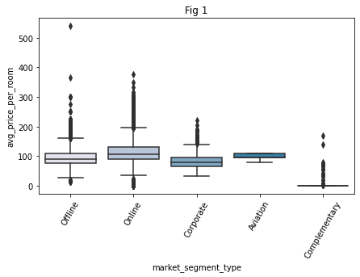

```python
plt.figure(figsize=(7,4))
plt.title("Fig 1")
sns.boxplot(x = "market_segment_type", y = "avg_price_per_room", data = df, palette = 'PuBu')
plt.xticks(rotation = 60)
plt.show()
```

**Observations**

- Rooms booked online have high variations in prices.
- The offline and corporate room prices are almost similar.
- Complementary market segment gets the rooms at very low prices, which makes sense.

#### Question 4: What percentage of bookings are canceled?

```python
print ('The percentage of bookings that are cancelled is',
       round(df[df['booking_status'] == "Canceled"].shape[0] / df.shape[0] * 100, 2),'%')
```

```
The percentage of bookings that are cancelled is 32.76 %
```

#### Question 5: Repeating guests are the guests who stay in the hotel often and are important to brand equity. What percentage of repeating guests cancel?

```python
repeat = df[df["repeated_guest"] == 1]

repeat.shape[0]
```

```
930
```

```python
print ('The percentage of bookings that are cancelled by repeating guests is',
       round(repeat[repeat['booking_status'] == "Canceled"].shape[0] / repeat.shape[0] * 100, 2),'%')
```

```
The percentage of bookings that are cancelled by repeating guests is 1.72 %
```

#### Question 6: Many guests have special requirements when booking a hotel room. Do these requirements affect booking cancellation?

```python
df.groupby("no_of_special_requests")["booking_status"].value_counts()
```

```
no_of_special_requests  booking_status
0                       Not_Canceled      11232
                        Canceled           8545
1                       Not_Canceled       8670
                        Canceled           2703
2                       Not_Canceled       3727
                        Canceled            637
3                       Not_Canceled        675
4                       Not_Canceled         78
5                       Not_Canceled          8
Name: booking_status, dtype: int64
```

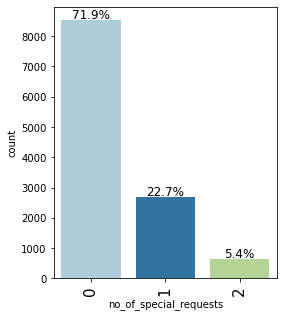

```python
canceled = df[df['booking_status'] == "Canceled"]
kept = df[df['booking_status'] == "Not_Canceled"]

bar(canceled, 'no_of_special_requests', perc=True)
```

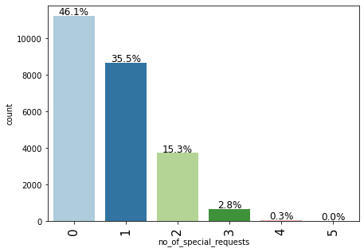

```python
bar(kept, 'no_of_special_requests', perc=True)
```

**Observations:**

- Number of special requests:
  - 3 or more: no bookings were canceled
  - 2: over 85% were not canceled
  - 1: over 75% were not canceled
  - 0: around 56% of bookings were not canceled
- Canceled vs Not Canceled
  - Out of bookings that happened to be canceled, 71.9% had 0 special requests.
  - Out of bookings that happened to NOT be canceled, 46.1% had 0 special requests, and 35.5% had 1.

### Univariate Analysis

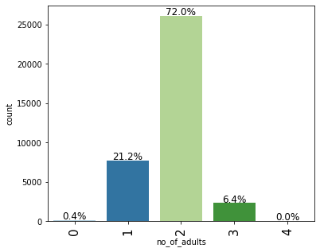

```python
bar(df, 'no_of_adults', perc=True)
```

**Observations:**

- 72% of the bookings were made for 2 adults.
- Many outliers, more so on the lower end of the range.

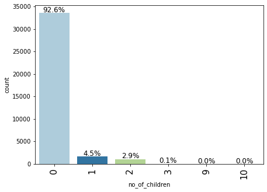

```python
bar(df, 'no_of_children', perc=True)
```

**Observations:**

- 93% of the customers didn't make reservations for children.
- There are some values in the data where the number of children is 9 or 10, which is highly unlikely.
- We will replace these values with the maximum value of 3 children.

```python
# replacing 9, and 10 children with 3

df["no_of_children"] = df["no_of_children"].replace([9, 10], 3)
```

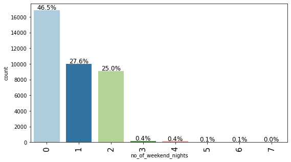

```python
bar(df, 'no_of_weekend_nights', perc=True)
```

**Observations:**

- 46.5% of the customers do not plan to spend the weekend in the hotel.
- The percentage of customers planning to spend 1 or 2 weekends in the hotel is almost the same

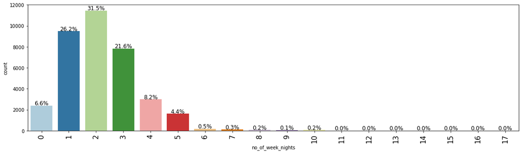

```python
bar(df, 'no_of_week_nights', perc=True)
```

**Observations:**

- Most bookings are made for 2 nights (31.5%) followed by 1 night (26.2%).
- A very small proportion of customers made the booking for more than 10 days.

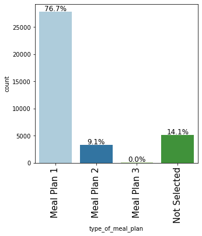

```python
bar(df, 'type_of_meal_plan', perc=True)
```

**Observations:**

- Most of the customers prefer meal plan 1 that is only breakfast.
- 14.1% of the customers didn't select a meal plan.

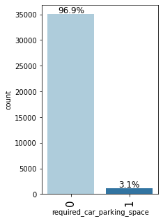

```python
bar(df, 'required_car_parking_space', perc=True)
```

```python
df['required_car_parking_space'].value_counts()
```

```
0    35151
1     1124
Name: required_car_parking_space, dtype: int64
```

**Observations:**

- Does the customer require a car parking space? (0 - No, 1- Yes)
- 96.9% of the customers do not require a car parking space.

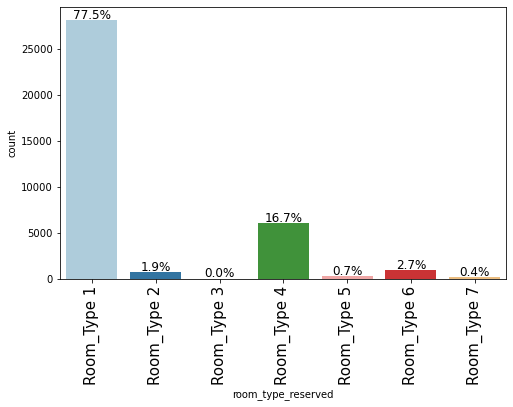

```python
bar(df, 'room_type_reserved', perc=True)
```

**Observations:**

- Around 77% of the customers booked Room_Type 1 followed by 17% of the customers booking Room_Type 4.

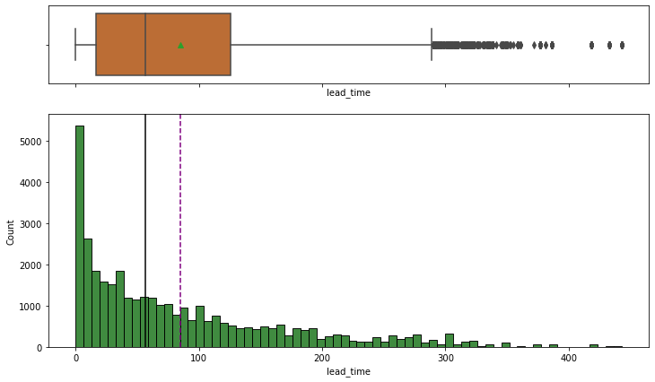

```python
histbox(df, 'lead_time')
```

```python
df['lead_time'].describe()
```

```
count   36275.00000
mean       85.23256
std        85.93082
min         0.00000
25%        17.00000
50%        57.00000
75%       126.00000
max       443.00000
Name: lead_time, dtype: float64
```

**Observations:**

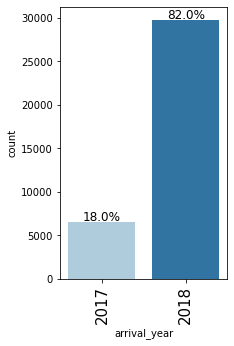

```python
bar(df, 'arrival_year', perc=True)
```

**Observations:**

- 82% of the hotel guests in this dataset booked a room in 2018.

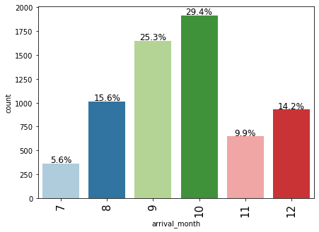

```python
year1 = df[df['arrival_year']==2017]
year2 = df[df['arrival_year']==2018]

bar(year1, "arrival_month", perc=True)
```

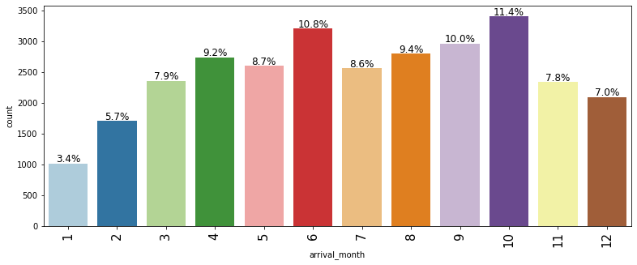

```python
bar(year2, "arrival_month", perc=True)
```

**Observations:**

- 2017 bookings cover only the last 6 months of the year, 2018 covers all.
- October consists of the highest number of bookings for both years. (29% in 2017, 11% in 2018).

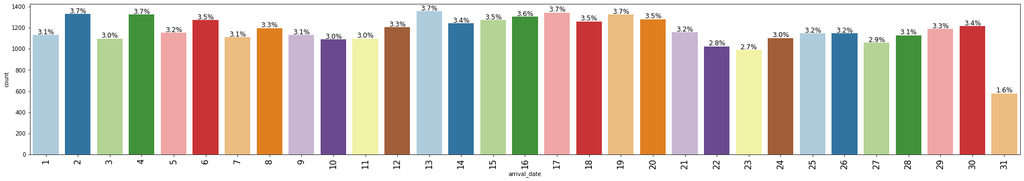

```python
bar(df, 'arrival_date', perc=True)
```

**Observations:**

- Arrival date is surprisingly evenly distributed among all the days of a month.

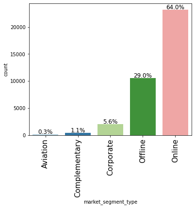

```python
bar(df, 'market_segment_type', perc=True)
```

**Observations:**

- 64% of the hotel bookings were made online followed by 29% of the bookings which were made offline.

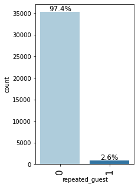

```python
bar(df, 'repeated_guest', perc=True)
```

```python
df['repeated_guest'].value_counts()
```

```
0    35345
1      930
Name: repeated_guest, dtype: int64
```

**Observations:**

- Is the customer a repeated guest? (0 - No, 1- Yes)
- The majority of customers are not repeating guests, this might be due to the dataset only including hotel stays for two years, something to look into.

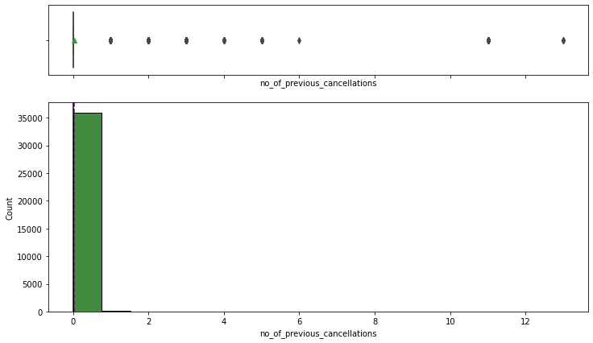

```python
histbox(df, 'no_of_previous_cancellations')
```

```python
df['no_of_previous_cancellations'].value_counts()
```

```
0     35937
1       198
2        46
3        43
11       25
5        11
4        10
13        4
6         1
Name: no_of_previous_cancellations, dtype: int64
```

**Observations:**

- Very few customers have more than one cancellation.
- Some customers canceled more than 12 times.

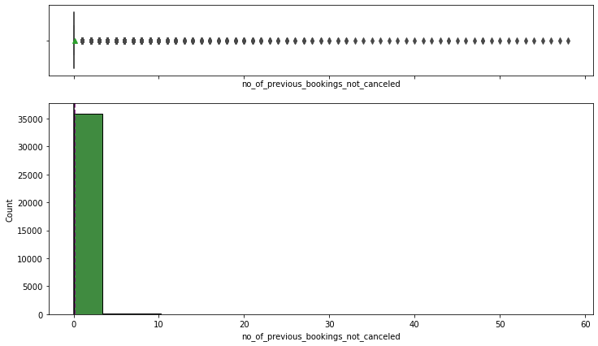

```python
histbox(df, 'no_of_previous_bookings_not_canceled')
```

```python
df['no_of_previous_bookings_not_canceled'].value_counts()[:10]
```

```
0     35463
1       228
2       112
3        80
4        65
5        60
6        36
7        24
8        23
10       19
Name: no_of_previous_bookings_not_canceled, dtype: int64
```

**Observations:**

- Very few customers have more than 1 booking not canceled previously.
- Some customers have not canceled their bookings around 60 times.

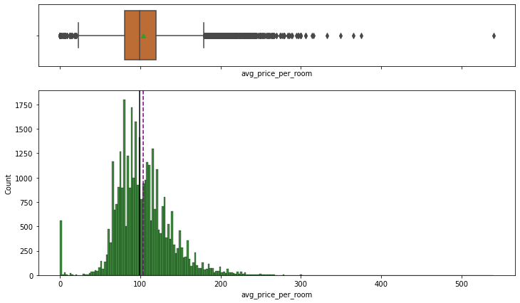

```python
histbox(df, 'avg_price_per_room')
```

```python
#large number of avg price = 0 dollars, see what some of it looks like:

zero = df[df["avg_price_per_room"] == 0]

zero.head()
```

|  | no_of_adults | no_of_children | no_of_weekend_nights | no_of_week_nights | type_of_meal_plan | required_car_parking_space | room_type_reserved | lead_time | arrival_year | arrival_month | arrival_date | market_segment_type | repeated_guest | no_of_previous_cancellations | no_of_previous_bookings_not_canceled | avg_price_per_room | no_of_special_requests | booking_status |
| --- | --- | --- | --- | --- | --- | --- | --- | --- | --- | --- | --- | --- | --- | --- | --- | --- | --- | --- |
| 63 | 1 | 0 | 0 | 1 | Meal Plan 1 | 0 | Room_Type 1 | 2 | 2017 | 9 | 10 | Complementary | 0 | 0 | 0 | 0.00000 | 1 | Not_Canceled |
| 145 | 1 | 0 | 0 | 2 | Meal Plan 1 | 0 | Room_Type 1 | 13 | 2018 | 6 | 1 | Complementary | 1 | 3 | 5 | 0.00000 | 1 | Not_Canceled |
| 209 | 1 | 0 | 0 | 0 | Meal Plan 1 | 0 | Room_Type 1 | 4 | 2018 | 2 | 27 | Complementary | 0 | 0 | 0 | 0.00000 | 1 | Not_Canceled |
| 266 | 1 | 0 | 0 | 2 | Meal Plan 1 | 0 | Room_Type 1 | 1 | 2017 | 8 | 12 | Complementary | 1 | 0 | 1 | 0.00000 | 1 | Not_Canceled |
| 267 | 1 | 0 | 2 | 1 | Meal Plan 1 | 0 | Room_Type 1 | 4 | 2017 | 8 | 23 | Complementary | 0 | 0 | 0 | 0.00000 | 1 | Not_Canceled |

```python
zero.groupby("market_segment_type")['avg_price_per_room'].count()
```

```
market_segment_type
Complementary    354
Online           191
Name: avg_price_per_room, dtype: int64
```

```python
df.groupby("market_segment_type")['avg_price_per_room'].count()
```

```
market_segment_type
Aviation           125
Complementary      391
Corporate         2017
Offline          10528
Online           23214
Name: avg_price_per_room, dtype: int64
```

```python
df['avg_price_per_room'].describe()
```

```
count   36275.00000
mean      103.42354
std        35.08942
min         0.00000
25%        80.30000
50%        99.45000
75%       120.00000
max       540.00000
Name: avg_price_per_room, dtype: float64
```

**Observations:**

- The distribution of average price per room is skewed to right. There are outliers on both sides.
- The average price of a room is around ~100 euros.
- There is 1 observation where the average price of the room is more than 500 euros. This observation is quite far away from the rest of the values. Instead of dropping it, we will clip this to the upper whisker (Q3 + 1.5 * IQR).
- With rooms with a price equal to 0:
  - It makes sense that most values with room prices equal to 0 are the rooms given as complimentary service given by the hotel.
  - The rooms booked online must be a part of some promotional campaign done by the hotel.

```python
# Calculating the 25th quantile
Q1 = df["avg_price_per_room"].quantile(0.25)

# Calculating the 75th quantile
Q3 = df["avg_price_per_room"].quantile(0.75)

# Calculating IQR
IQR = Q3 - Q1

# Calculating value of upper whisker
Upper_Whisker = Q3 + 1.5 * IQR
Upper_Whisker
```

```
179.55
```

```python
# assigning the outliers the value of upper whisker
df.loc[df["avg_price_per_room"] >= 500, "avg_price_per_room"] = Upper_Whisker
```

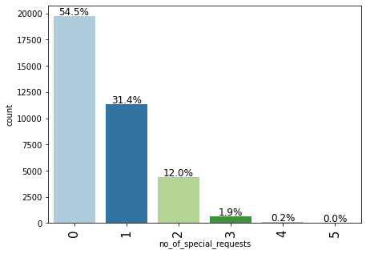

```python
bar(df,'no_of_special_requests', perc=True)
```

**Observations:**

- The majority (54.5%) of hotel guests did not put in any special requests.
- About a third put in 1 request, and 12% put in 2.

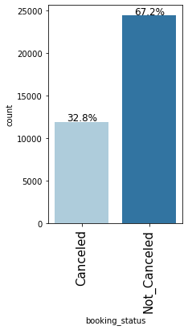

```python
bar(df, 'booking_status', perc=True)
```

**Observations:**

- The majority (67.2%) of hotel bookings are not cancelled.

`required_car_parking_space` and `repeated_guest` are both coded as (0 - No, 1 - Yes). **Let's do this for booking_status, code (0 - Not_Canceled, 1 - Canceled).**

```python
df["booking_status"] = df["booking_status"].apply(lambda x: 1 if x == "Canceled" else 0)
```

### Bivariate Analysis

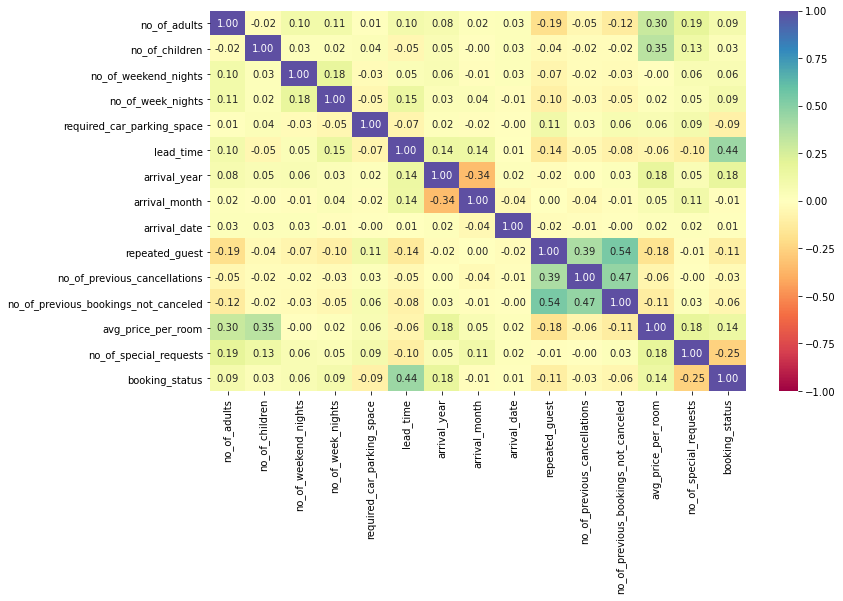

```python
corr_cols = df.select_dtypes(include=np.number).columns.tolist()

plt.figure(figsize=(12, 7))
sns.heatmap(
    df[corr_cols].corr(), annot=True, vmin=-1, vmax=1, fmt=".2f", cmap="Spectral"
)
plt.show()
```

**Observations:**

- There's a positive correlation between the number of customers (adults and children) and the average price per room.
  - This makes sense as more the number of customers more rooms they will require thus increasing the cost.
- There's a negative correlation between average room price and repeated guests. The hotel might be giving some loyalty benefits to the customers.
- There's a positive correlation between the number of previous bookings canceled and previous bookings not canceled by a customer and repeated guest.
- There's a positive correlation between lead time and the number of weeknights a customer is planning to stay in the hotel.
- There's a positive correlation between booking status and lead time, indicating higher the lead time higher are the chances of cancellation. We will analyze it further.
- There's a negative correlation between the number of special requests from the customer and the booking status, indicating if a customer has made some special requests the chances of cancellation might decrease. We will analyze it further.

```python
# function to plot stacked barplot

def stack(data, predictor, target):
    """
    Print the category counts and plot a stacked bar chart

    data: dataframe
    predictor: independent variable
    target: target variable
    """
    count = data[predictor].nunique()
    sorter = data[target].value_counts().index[-1]
    tab1 = pd.crosstab(data[predictor], data[target], margins=True).sort_values(
        by=sorter, ascending=False
    )
    print(tab1)
    print("-" * 120)
    tab = pd.crosstab(data[predictor], data[target], normalize="index").sort_values(
        by=sorter, ascending=False
    )
    tab.plot(kind="bar", stacked=True, figsize=(count + 5, 6))
    plt.legend(
        loc="lower left", frameon=False,
    )
    plt.legend(loc="upper left", bbox_to_anchor=(1, 1))
    plt.show()
```

```python
# function to plot distributions with respect to target


def dist_target(data, predictor, target):

    fig, axs = plt.subplots(2, 2, figsize=(12, 10))

    target_uniq = data[target].unique()

    axs[0, 0].set_title("Distribution of target for target=" + str(target_uniq[0]))
    sns.histplot(
        data=data[data[target] == target_uniq[0]],
        x=predictor,
        kde=True,
        ax=axs[0, 0],
        color="teal",
        stat="density",
    )

    axs[0, 1].set_title("Distribution of target for target=" + str(target_uniq[1]))
    sns.histplot(
        data=data[data[target] == target_uniq[1]],
        x=predictor,
        kde=True,
        ax=axs[0, 1],
        color="orange",
        stat="density",
    )

    axs[1, 0].set_title("Boxplot w.r.t target")
    sns.boxplot(data=data, x=target, y=predictor, ax=axs[1, 0], palette="gist_rainbow")

    axs[1, 1].set_title("Boxplot (without outliers) w.r.t target")
    sns.boxplot(
        data=data,
        x=target,
        y=predictor,
        ax=axs[1, 1],
        showfliers=False,
        palette="gist_rainbow",
    )

    plt.tight_layout()
    plt.show()
```

#### Leading Question 1 asks what the busiest months of the hotel are.

**Observations:**

```
booking_status      0      1    All
arrival_month
All             24390  11885  36275
10               3437   1880   5317
9                3073   1538   4611
8                2325   1488   3813
7                1606   1314   2920
6                1912   1291   3203
4                1741    995   2736
5                1650    948   2598
11               2105    875   2980
3                1658    700   2358
2                1274    430   1704
12               2619    402   3021
1                 990     24   1014
------------------------------------------------------------------------------------------------------------------------
```

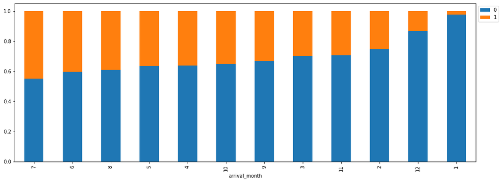

```python
# check month of booking against cancel/not cancelled

stack(df, 'arrival_month', 'booking_status')
```

**Observations:**

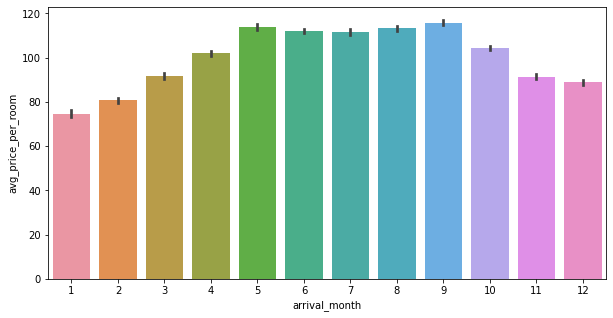

```python
# relationship between average room price and arrival month

plt.figure(figsize=(10, 5))
sns.barplot(x = "arrival_month", y="avg_price_per_room", data=df)
plt.show()
```

**Observations:**

- Months May - September are around the same in terms of room price.
- Busiest month (October) room price lower than expected

#### Fig 1 (from Leading Question 3): compares market segment to average room price.

Observations:

```python
# compare market segment to bookings

df.groupby("market_segment_type")["booking_status"].value_counts()
```

```
market_segment_type  booking_status
Aviation             0                    88
                     1                    37
Complementary        0                   391
Corporate            0                  1797
                     1                   220
Offline              0                  7375
                     1                  3153
Online               0                 14739
                     1                  8475
Name: booking_status, dtype: int64
```

```
booking_status           0      1    All
market_segment_type
All                  24390  11885  36275
Online               14739   8475  23214
Offline               7375   3153  10528
Corporate             1797    220   2017
Aviation                88     37    125
Complementary          391      0    391
------------------------------------------------------------------------------------------------------------------------
```

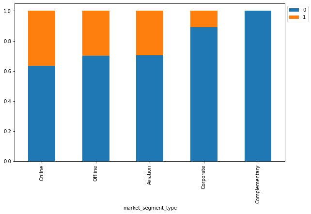

```python
stack(df, 'market_segment_type', 'booking_status')
```

**Observations:**

- Around 40% of the online booking were canceled.
- Bookings made offline are less prone to cancellations.
- Corporate segment shows very low cancellations.

```python
df.groupby("booking_status")["avg_price_per_room"].value_counts()
```

```
booking_status  avg_price_per_room
0               65.00000              758
                75.00000              578
                0.00000               539
                95.00000              483
                90.00000              459
                                     ...
1               284.10000               1
                299.33000               1
                306.00000               1
                316.00000               1
                365.00000               1
Name: avg_price_per_room, Length: 4941, dtype: int64
```

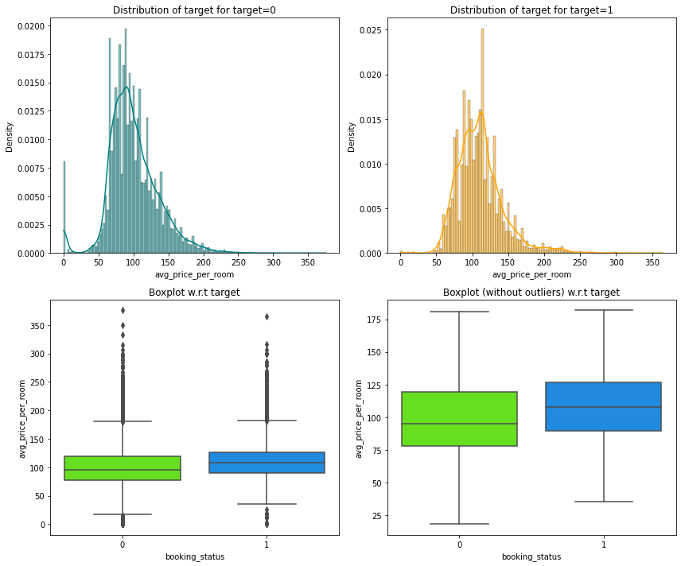

```python
dist_target(df, 'avg_price_per_room', 'booking_status')
```

**Observations:**

- The distribution of price for canceled bookings and not canceled bookings is quite similar.
- The prices for the canceled bookings are slightly higher than the bookings which were not canceled.

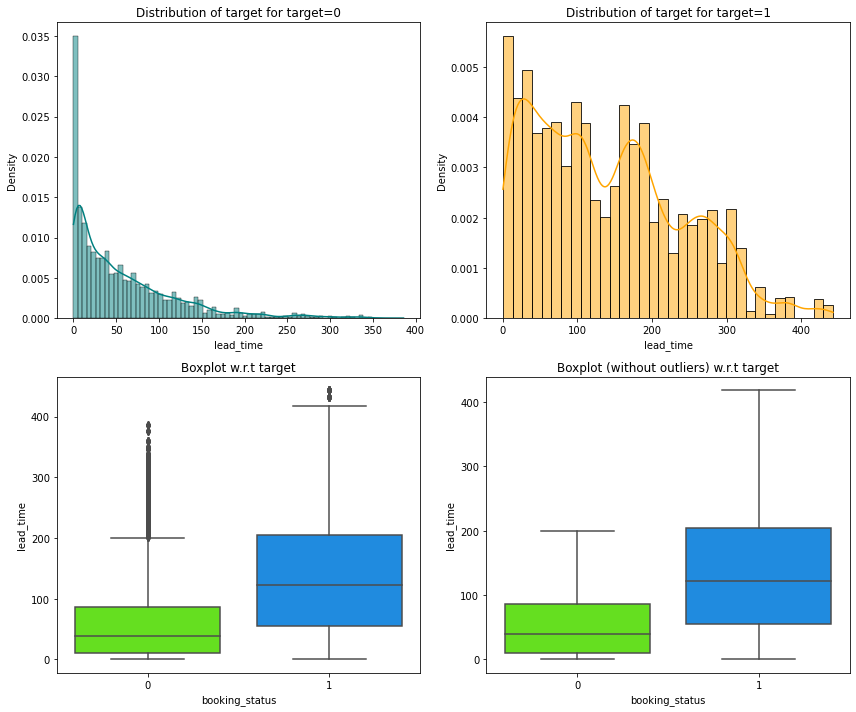

```python
# relationship between lead time and booking status

dist_target(df, 'lead_time', 'booking_status')
```

**Observations:**

- There's a big difference in the median value of lead time for bookings that were canceled and bookings that were not canceled.
- Higher the lead time higher are the chances of a booking being canceled.

#### Leading Question 5 details how many repeating guests have cancellations.

In the dataset, 2.6% are repeating guests. The percentage of bookings that are cancelled by repeating guests is 1.72 %. The percentage of bookings that are cancelled in general is 32.8%.

#### Leading Question 6 details how special requests affect booking status/cancellations.

**Observations:**

- Number of special requests:
  - 3 or more: no bookings were canceled
  - 2: over 85% were not canceled
  - 1: over 75% were not canceled
  - 0: around 56% of bookings were not canceled
- Canceled vs Not Canceled
  - Out of bookings that happened to be canceled, 71.9% had 0 special requests.
  - Out of bookings that happened to NOT be canceled, 46.1% had 0 special requests, and 35.5% had 1.

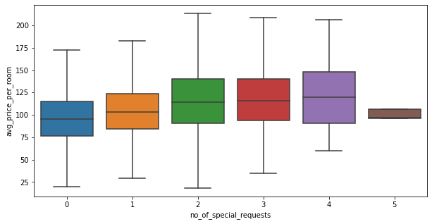

```python
# relationship between special requests and average room price

plt.figure(figsize=(10, 5))
sns.boxplot(
    data=df,
    x="no_of_special_requests",
    y="avg_price_per_room",
    showfliers=False,  # turning off the outliers
)
plt.show()
```

**Observations:**

- The median prices of the rooms where some special requests were made by the customers are slightly higher than the rooms where customer didn't make any requests.

**Generally people travel with their spouse and children for vacations or other activities. Let's create a new dataframe of the customers who traveled with their families and analyze the impact on booking status.**

```python
family = df[(df["no_of_children"] >= 0) & (df["no_of_adults"] > 1)]

family['total'] = family['no_of_children'] + family['no_of_adults']

family.head()
```

|  | no_of_adults | no_of_children | no_of_weekend_nights | no_of_week_nights | type_of_meal_plan | required_car_parking_space | room_type_reserved | lead_time | arrival_year | arrival_month | arrival_date | market_segment_type | repeated_guest | no_of_previous_cancellations | no_of_previous_bookings_not_canceled | avg_price_per_room | no_of_special_requests | booking_status | total |
| --- | --- | --- | --- | --- | --- | --- | --- | --- | --- | --- | --- | --- | --- | --- | --- | --- | --- | --- | --- |
| 0 | 2 | 0 | 1 | 2 | Meal Plan 1 | 0 | Room_Type 1 | 224 | 2017 | 10 | 2 | Offline | 0 | 0 | 0 | 65.00000 | 0 | 0 | 2 |
| 1 | 2 | 0 | 2 | 3 | Not Selected | 0 | Room_Type 1 | 5 | 2018 | 11 | 6 | Online | 0 | 0 | 0 | 106.68000 | 1 | 0 | 2 |
| 3 | 2 | 0 | 0 | 2 | Meal Plan 1 | 0 | Room_Type 1 | 211 | 2018 | 5 | 20 | Online | 0 | 0 | 0 | 100.00000 | 0 | 1 | 2 |
| 4 | 2 | 0 | 1 | 1 | Not Selected | 0 | Room_Type 1 | 48 | 2018 | 4 | 11 | Online | 0 | 0 | 0 | 94.50000 | 0 | 1 | 2 |
| 5 | 2 | 0 | 0 | 2 | Meal Plan 2 | 0 | Room_Type 1 | 346 | 2018 | 9 | 13 | Online | 0 | 0 | 0 | 115.00000 | 1 | 1 | 2 |

```
booking_status      0     1    All
total
All             18456  9985  28441
2               15506  8213  23719
3                2425  1368   3793
4                 514   398    912
5                  11     6     17
------------------------------------------------------------------------------------------------------------------------
```

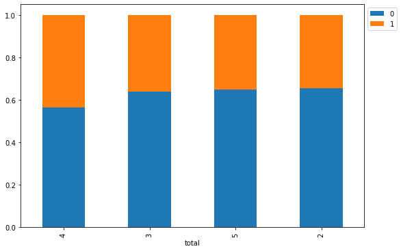

```python
stack(family, 'total', 'booking_status')
```

**Observations:**